# R Notebook

# Introduction:

This phase of the project is focused on reviewing and improving on the previous phases in the project. In deliverable 2, I used teaching salaries data to create a model. I specifically used the “percent change in salaries” data in my model. That model was not very successful, so in this deliverable I want to try to use some of the other data in the salaries dataset to try to create a better model.

```r
include <- function(library_name){
  if( !(library_name %in% installed.packages()) )
    install.packages(library_name)
  library(library_name, character.only=TRUE)
}
include("tidyverse")
include("rvest")
include("tidyr")
include("knitr")
#purl("deliverable1.Rmd", output = "part1.r")
source("part1.r")
purl("deliverable2.Rmd", output = "part2.r")
source("part2.r")
```

For reference, here is a print out of the data that we are working with. I have the education_numbers data which has the number of graduates at each level for each year chunk by state. I then have the salaries data that has the salary by state for each year chunk.

```r
print(education_numbers)
```

```
## # A tibble: 3,662 x 22
##    FIPS_Code State `1970_Less_Than… `1970_High_Scho… `1970_Some_Coll…
##    <chr>     <chr>            <dbl>            <dbl>            <dbl>
##  1 00000     US            52373312         34158051         11650730
##  2 01000     AL             1062306           468269           136287
##  3 01001     AL                6611             3757              933
##  4 01003     AL               18726             8426             2334
##  5 01005     AL                8120             2242              581
##  6 01007     AL                5272             1402              238
##  7 01009     AL               10677             3440              626
##  8 01011     AL                4245              958              305
##  9 01013     AL                8353             2459              499
## 10 01015     AL               30535            13804             3823
## # … with 3,652 more rows, and 17 more variables:
## #   `1970_Bachelor_Degree_Or_Higher` <dbl>,
## #   `1980_Less_Than_High_School_Diploma` <dbl>,
## #   `1980_High_School_Diploma_Only` <dbl>, `1980_Some_College` <dbl>,
## #   `1980_Bachelor_Degree_Or_Higher` <dbl>,
## #   `1990_Less_Than_High_School_Diploma` <dbl>,
## #   `1990_High_School_Diploma_Only` <dbl>, `1990_Some_College` <dbl>,
## #   `1990_Bachelor_Degree_Or_Higher` <dbl>,
## #   `2000_Less_Than_High_School_Diploma` <dbl>,
## #   `2000_High_School_Diploma_Only` <dbl>, `2000_Some_College` <dbl>,
## #   `2000_Bachelor_Degree_Or_Higher` <dbl>,
## #   `2013-17_Less_Than_High_School_Diploma` <dbl>,
## #   `2013-17_High_School_Diploma_Only` <dbl>, `2013-17_Some_College` <dbl>,
## #   `2013-17_Bachelor_Degree_Or_Higher` <dbl>
```

```r
print(salaries)
```

```
## # A tibble: 52 x 16
##    State `Constant_2016-… `Constant_2016-… `Constant_2016-… `Constant_2016-…
##    <chr> <chr>            <chr>            <chr>            <chr>
##  1 AK    67834            85050            82468            66597
##  2 AL    43797            40821            47448            52588
##  3 AR    40514            38443            42716            47854
##  4 AZ    55957            47054            56189            52894
##  5 CA    66261            56325            72616            68342
##  6 CO    49854            50652            58780            54701
##  7 CT    59496            50727            77323            74219
##  8 DC    66068            69359            73388            67477
##  9 DE    57910            50473            63785            63691
## 10 FL    54036            44225            55044            52636
## # … with 42 more rows, and 11 more variables:
## #   `Constant_2016-17_dollars:2009-10` <chr>,
## #   `Constant_2016-17_dollars:2015-16` <chr>,
## #   `Constant_2016-17_dollars:2016-17` <chr>, `Current_Dollars:1969-70` <chr>,
## #   `Current_Dollars:1979-80` <chr>, `Current_Dollars:1989-90` <chr>,
## #   `Current_Dollars:1999-2000` <chr>, `Current_Dollars:2009-10` <chr>,
## #   `Current_Dollars:2015-16` <chr>, `Current_Dollars:2016-17` <chr>,
## #   `Percent_change_1999-2000_to_2016-17` <chr>
```

# Creating two new Models:

For this model I am going to use the salary information and the number of graduates information. I am going to create a model using the salary data using the time period’s current dollar and then also using the constant 2016-17 dollar. I want to see if one works better than the other since one model will account for inflation and the other will not account for any inflation. For this model I am going to try to predict the number of high school graduates for 2013-2017. I am choosing to use only the data for high school diploma and below a high school diploma since teaching salaries are more related to the high school data than college data. In order to get this model to work, I had to some changes to deliverable 2 since some of the data was being stored as a factor instead of being stored as a double. I had to simply change the types of those variables in deliverable 2.

```r
library(caret)
set.seed(125)
train.control <- trainControl(method = "cv", number = 10)

sample_selection <- createDataPartition(education_sum_numbers$`2013-17_High_School_Diploma_Only`, p = 0.75, list = FALSE)
train <- education_sum_numbers[sample_selection, ]
test <- education_sum_numbers[-sample_selection, ]

train_model_current_dollars <- train(`2013-17_High_School_Diploma_Only` ~ `1970_Less_Than_High_School_Diploma` + `1970_High_School_Diploma_Only` + `1980_Less_Than_High_School_Diploma` + `1980_High_School_Diploma_Only` + `1990_Less_Than_High_School_Diploma` + `1990_High_School_Diploma_Only` + `2000_Less_Than_High_School_Diploma` + `2000_High_School_Diploma_Only` + `2013-17_Less_Than_High_School_Diploma` + `Current_Dollars:1969-70` + `Current_Dollars:1979-80` + `Current_Dollars:1989-90` + `Current_Dollars:1999-2000` + `Current_Dollars:2009-10` +   `Current_Dollars:2015-16` + `Current_Dollars:2016-17`, data = train, method = "lm", trControl = train.control)

summary(train_model_current_dollars)
```

```
##
## Call:
## lm(formula = .outcome ~ ., data = dat)
##
## Residuals:
##     Min      1Q  Median      3Q     Max
## -101586  -45270   -1676   44220   97120
##
## Coefficients:
##                                                 Estimate Std. Error t value
## (Intercept)                                    4.385e+04  1.695e+05   0.259
## `\\`1970_Less_Than_High_School_Diploma\\``    -8.746e-05  2.765e-01   0.000
## `\\`1970_High_School_Diploma_Only\\``         -1.553e-01  3.904e-01  -0.398
## `\\`1980_Less_Than_High_School_Diploma\\``    -1.308e-01  4.058e-01  -0.322
## `\\`1980_High_School_Diploma_Only\\``         -3.308e-01  3.289e-01  -1.006
## `\\`1990_Less_Than_High_School_Diploma\\``    -1.514e+00  4.167e-01  -3.633
## `\\`1990_High_School_Diploma_Only\\``          1.306e-01  2.685e-01   0.486
## `\\`2000_Less_Than_High_School_Diploma\\``     2.482e+00  5.506e-01   4.507
## `\\`2000_High_School_Diploma_Only\\``          1.493e+00  2.200e-01   6.787
## `\\`2013-17_Less_Than_High_School_Diploma\\`` -1.011e+00  3.275e-01  -3.088
## `\\`Current_Dollars:1969-70\\``               -2.442e+01  3.321e+01  -0.735
## `\\`Current_Dollars:1979-80\\``                9.391e+00  9.799e+00   0.958
## `\\`Current_Dollars:1989-90\\``               -6.599e+00  8.646e+00  -0.763
## `\\`Current_Dollars:1999-2000\\``             -7.200e+00  7.592e+00  -0.948
## `\\`Current_Dollars:2009-10\\``                7.005e+00  8.001e+00   0.876
## `\\`Current_Dollars:2015-16\\``                3.864e+01  3.821e+01   1.011
## `\\`Current_Dollars:2016-17\\``               -3.635e+01  3.514e+01  -1.034
##                                               Pr(>|t|)
## (Intercept)                                   0.798099
## `\\`1970_Less_Than_High_School_Diploma\\``    0.999750
## `\\`1970_High_School_Diploma_Only\\``         0.694440
## `\\`1980_Less_Than_High_School_Diploma\\``    0.750213
## `\\`1980_High_School_Diploma_Only\\``         0.324906
## `\\`1990_Less_Than_High_School_Diploma\\``    0.001392 **
## `\\`1990_High_School_Diploma_Only\\``         0.631376
## `\\`2000_Less_Than_High_School_Diploma\\``    0.000159 ***
## `\\`2000_High_School_Diploma_Only\\``         6.37e-07 ***
## `\\`2013-17_Less_Than_High_School_Diploma\\`` 0.005193 **
## `\\`Current_Dollars:1969-70\\``               0.469547
## `\\`Current_Dollars:1979-80\\``               0.347862
## `\\`Current_Dollars:1989-90\\``               0.453129
## `\\`Current_Dollars:1999-2000\\``             0.352847
## `\\`Current_Dollars:2009-10\\``               0.390297
## `\\`Current_Dollars:2015-16\\``               0.322373
## `\\`Current_Dollars:2016-17\\``               0.311706
## ---
## Signif. codes:  0 '***' 0.001 '**' 0.01 '*' 0.05 '.' 0.1 ' ' 1
##
## Residual standard error: 71500 on 23 degrees of freedom
## Multiple R-squared:      1,  Adjusted R-squared:  0.9999
## F-statistic: 4.096e+04 on 16 and 23 DF,  p-value: < 2.2e-16
```

```r
prediction_current_dollars <- train_model_current_dollars %>% predict(test)

R2(prediction_current_dollars, test$`2013-17_High_School_Diploma_Only`)
```

```
## [1] 0.9972924
```

```r
MAE(prediction_current_dollars, test$`2013-17_High_School_Diploma_Only`)
```

```
## [1] 96532.11
```

```r
RMSE(prediction_current_dollars, test$`2013-17_High_School_Diploma_Only`)
```

```
## [1] 194413.4
```

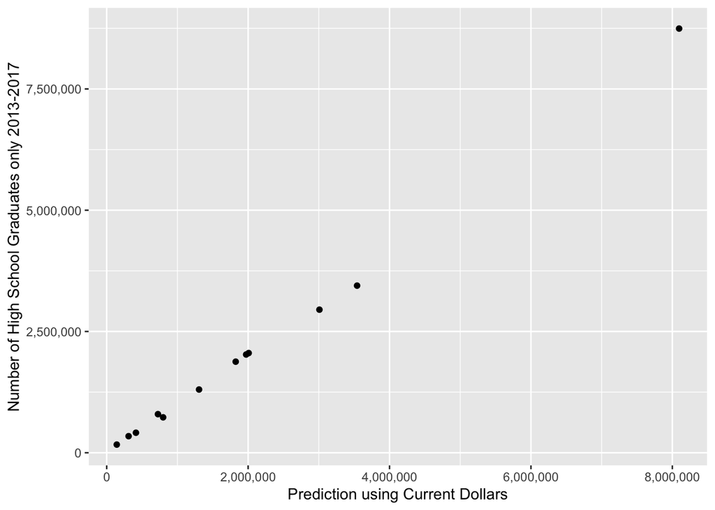

```r
ggplot(test, aes(x = prediction_current_dollars, y = `2013-17_High_School_Diploma_Only`)) + geom_point()  + scale_x_continuous(name="Prediction using Current Dollars", labels = scales::comma) + scale_y_continuous(name="Number of High School Graduates only 2013-2017", labels = scales::comma)
```

```r
library(caret)
set.seed(125)
sample_selection <- createDataPartition(education_sum_numbers$`2013-17_High_School_Diploma_Only`, p = 0.75, list = FALSE)
train <- education_sum_numbers[sample_selection, ]
test <- education_sum_numbers[-sample_selection, ]

train_model_constant_dollars <- train(`2013-17_High_School_Diploma_Only` ~ `1970_Less_Than_High_School_Diploma` + `1970_High_School_Diploma_Only` + `1980_Less_Than_High_School_Diploma` + `1980_High_School_Diploma_Only` + `1990_Less_Than_High_School_Diploma` + `1990_High_School_Diploma_Only` + `2000_Less_Than_High_School_Diploma` + `2000_High_School_Diploma_Only` + `2013-17_Less_Than_High_School_Diploma` + `Constant_2016-17_dollars:1969-70` + `Constant_2016-17_dollars:1979-80` + `Constant_2016-17_dollars:1989-90` + `Constant_2016-17_dollars:1999-2000` + `Constant_2016-17_dollars:2009-10` + `Constant_2016-17_dollars:2015-16` +    `Constant_2016-17_dollars:2016-17`, data = train, method = "lm", trControl = train.control)

summary(train_model_constant_dollars)
```

```
##
## Call:
## lm(formula = .outcome ~ ., data = dat)
##
## Residuals:
##     Min      1Q  Median      3Q     Max
## -101583  -45286   -1685   44216   97112
##
## Coefficients:
##                                                 Estimate Std. Error t value
## (Intercept)                                    4.391e+04  1.694e+05   0.259
## `\\`1970_Less_Than_High_School_Diploma\\``    -1.542e-04  2.765e-01  -0.001
## `\\`1970_High_School_Diploma_Only\\``         -1.552e-01  3.904e-01  -0.398
## `\\`1980_Less_Than_High_School_Diploma\\``    -1.307e-01  4.058e-01  -0.322
## `\\`1980_High_School_Diploma_Only\\``         -3.309e-01  3.288e-01  -1.006
## `\\`1990_Less_Than_High_School_Diploma\\``    -1.514e+00  4.167e-01  -3.633
## `\\`1990_High_School_Diploma_Only\\``          1.306e-01  2.685e-01   0.486
## `\\`2000_Less_Than_High_School_Diploma\\``     2.482e+00  5.506e-01   4.508
## `\\`2000_High_School_Diploma_Only\\``          1.493e+00  2.200e-01   6.788
## `\\`2013-17_Less_Than_High_School_Diploma\\`` -1.011e+00  3.275e-01  -3.088
## `\\`Constant_2016-17_dollars:1969-70\\``      -3.801e+00  5.170e+00  -0.735
## `\\`Constant_2016-17_dollars:1979-80\\``       3.004e+00  3.135e+00   0.958
## `\\`Constant_2016-17_dollars:1989-90\\``      -3.454e+00  4.524e+00  -0.763
## `\\`Constant_2016-17_dollars:1999-2000\\``    -5.023e+00  5.296e+00  -0.948
## `\\`Constant_2016-17_dollars:2009-10\\``       6.255e+00  7.145e+00   0.875
## `\\`Constant_2016-17_dollars:2015-16\\``       3.796e+01  3.751e+01   1.012
## `\\`Constant_2016-17_dollars:2016-17\\``      -3.636e+01  3.513e+01  -1.035
##                                               Pr(>|t|)
## (Intercept)                                   0.797828
## `\\`1970_Less_Than_High_School_Diploma\\``    0.999560
## `\\`1970_High_School_Diploma_Only\\``         0.694606
## `\\`1980_Less_Than_High_School_Diploma\\``    0.750387
## `\\`1980_High_School_Diploma_Only\\``         0.324777
## `\\`1990_Less_Than_High_School_Diploma\\``    0.001391 **
## `\\`1990_High_School_Diploma_Only\\``         0.631315
## `\\`2000_Less_Than_High_School_Diploma\\``    0.000159 ***
## `\\`2000_High_School_Diploma_Only\\``         6.37e-07 ***
## `\\`2013-17_Less_Than_High_School_Diploma\\`` 0.005188 **
## `\\`Constant_2016-17_dollars:1969-70\\``      0.469589
## `\\`Constant_2016-17_dollars:1979-80\\``      0.347833
## `\\`Constant_2016-17_dollars:1989-90\\``      0.452973
## `\\`Constant_2016-17_dollars:1999-2000\\``    0.352767
## `\\`Constant_2016-17_dollars:2009-10\\``      0.390440
## `\\`Constant_2016-17_dollars:2015-16\\``      0.322089
## `\\`Constant_2016-17_dollars:2016-17\\``      0.311432
## ---
## Signif. codes:  0 '***' 0.001 '**' 0.01 '*' 0.05 '.' 0.1 ' ' 1
##
## Residual standard error: 71500 on 23 degrees of freedom
## Multiple R-squared:      1,  Adjusted R-squared:  0.9999
## F-statistic: 4.096e+04 on 16 and 23 DF,  p-value: < 2.2e-16
```

```r
prediction_constant_dollars <- train_model_constant_dollars %>% predict(test)

R2(prediction_constant_dollars, test$`2013-17_High_School_Diploma_Only`)
```

```
## [1] 0.9972925
```

```r
MAE(prediction_constant_dollars, test$`2013-17_High_School_Diploma_Only`)
```

```
## [1] 96540.51
```

```r
RMSE(prediction_constant_dollars, test$`2013-17_High_School_Diploma_Only`)
```

```
## [1] 194419.3
```

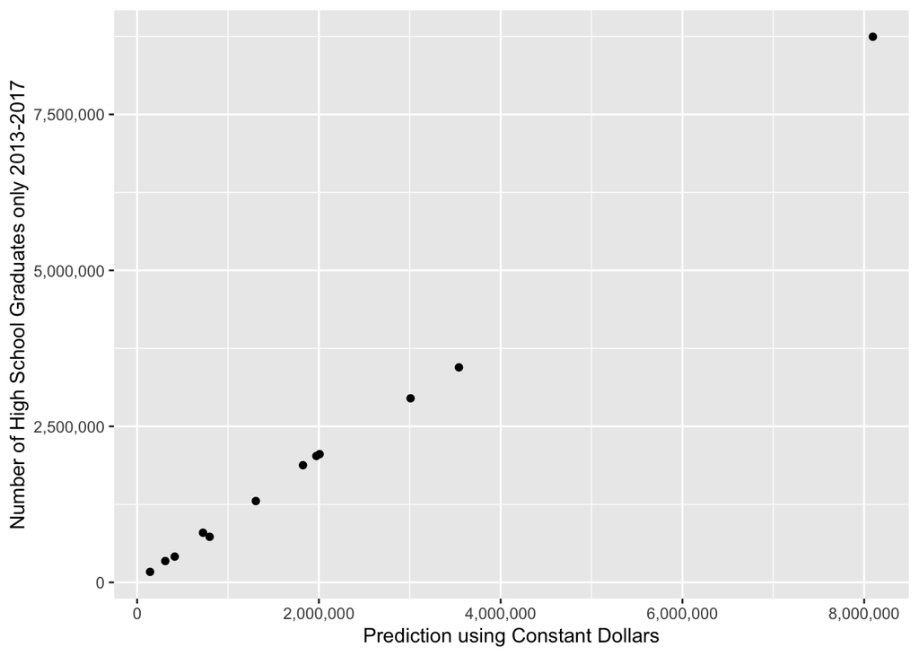

```r
ggplot(test, aes(x = prediction_constant_dollars, y = `2013-17_High_School_Diploma_Only`)) + geom_point() + scale_x_continuous(name="Prediction using Constant Dollars", labels = scales::comma) + scale_y_continuous(name="Number of High School Graduates only 2013-2017", labels = scales::comma)
```

# Model Summaries:

These two models have very similar results. Both models have a very low overall p-value. This shows that the models are good; however when you look at the p-value for the different coefficients, only 2013-17_Less_Than_High_School_Diploma, 2000_High_School_Diploma_Only, 2000_Less_Than_High_School_Diploma, and 1990_Less_Than_High_School_Diploma are the only coefficients with low p-values. What this shows is that although these are good models, it is mainly because of those coefficient which is not what I was trying to do with this model.  
The reason that I included those variables in my models was because I wanted to include the data for both the change in salary as well as the data for the change in number of students at the different levels. I thought that this would be necessary for the models. I think that if I only included the salary data in these models and removed the number of students data, then the model would not have a very low overall p-value. For this model, I used the k-fold cross-validation technique which randomly splits the data set into k-subsets, it then reserves one subset and trains the model on all other subsets. From there it tests the model on the reserved subset and record the prediction error. It repeat this process until each of the k subsets has served as the test set. By doing this the model is able to compute the average of the k recorded errors.

# Final Thoughts